# DATA 607 Assignment 1

Susanna Wong

2023-01-30

# Introduction

The article provide information for college students on choosing a major that will allow them to have a higher chance of economic success. The major category, unemployment rate, and gender can play a role in their economic success.

# Data

The data set I used is from FiveThirtyEight. The article and data can be found in the links below. https://fivethirtyeight.com/features/the-economic-guide-to-picking-a-college-major/ https://github.com/fivethirtyeight/data/tree/master/college-majors

FiveThirtyEight gathered their data from American Community Survey 2010-2012 Public Use Mircrodata Series.

```r
library(tidyverse)
library(DT)
recentgrad <- read.csv('https://raw.githubusercontent.com/fivethirtyeight/data/master/college-majors/recent-grads.csv')
womenstem <- read.csv('https://raw.githubusercontent.com/fivethirtyeight/data/master/college-majors/women-stem.csv')
datatable(womenstem)
```

|  | Rank | Major_code | Major | Major_category | Total | Men | Women | ShareWomen | Median |
| --- | --- | --- | --- | --- | --- | --- | --- | --- | --- |
| 1 | 1 | 2419 | PETROLEUM ENGINEERING | Engineering | 2339 | 2057 | 282 | 0.120564344 | 110000 |
| 2 | 2 | 2416 | MINING AND MINERAL ENGINEERING | Engineering | 756 | 679 | 77 | 0.101851852 | 75000 |
| 3 | 3 | 2415 | METALLURGICAL ENGINEERING | Engineering | 856 | 725 | 131 | 0.153037383 | 73000 |
| 4 | 4 | 2417 | NAVAL ARCHITECTURE AND MARINE ENGINEERING | Engineering | 1258 | 1123 | 135 | 0.107313196 | 70000 |
| 5 | 5 | 2418 | NUCLEAR ENGINEERING | Engineering | 2573 | 2200 | 373 | 0.144966965 | 65000 |
| 6 | 6 | 2405 | CHEMICAL ENGINEERING | Engineering | 32260 | 21239 | 11021 | 0.341630502 | 65000 |
| 7 | 7 | 5001 | ASTRONOMY AND ASTROPHYSICS | Physical Sciences | 1792 | 832 | 960 | 0.535714286 | 62000 |
| 8 | 8 | 2414 | MECHANICAL ENGINEERING | Engineering | 91227 | 80320 | 10907 | 0.119558903 | 60000 |
| 9 | 9 | 2401 | AEROSPACE ENGINEERING | Engineering | 15058 | 12953 | 2105 | 0.139792801 | 60000 |
| 10 | 10 | 2408 | ELECTRICAL ENGINEERING | Engineering | 81527 | 65511 | 16016 | 0.196450256 | 60000 |

[output cut: 66 more lines]

```r
datatable(recentgrad)
```

|  | Rank | Major_code | Major | Total | Men | Women | Major_category | ShareWomen | Sample_size | Employed | Full_time | Part_time | Full_time_year_round | Unemployed | Unemployment_rate | Median | P25th | P75th | College_jobs | Non_college_jobs | Low_wage_jobs |
| --- | --- | --- | --- | --- | --- | --- | --- | --- | --- | --- | --- | --- | --- | --- | --- | --- | --- | --- | --- | --- | --- |
| 1 | 1 | 2419 | PETROLEUM ENGINEERING | 2339 | 2057 | 282 | Engineering | 0.120564344 | 36 | 1976 | 1849 | 270 | 1207 | 37 | 0.018380527 | 110000 | 95000 | 125000 | 1534 | 364 | 193 |
| 2 | 2 | 2416 | MINING AND MINERAL ENGINEERING | 756 | 679 | 77 | Engineering | 0.101851852 | 7 | 640 | 556 | 170 | 388 | 85 | 0.117241379 | 75000 | 55000 | 90000 | 350 | 257 | 50 |
| 3 | 3 | 2415 | METALLURGICAL ENGINEERING | 856 | 725 | 131 | Engineering | 0.153037383 | 3 | 648 | 558 | 133 | 340 | 16 | 0.024096386 | 73000 | 50000 | 105000 | 456 | 176 | 0 |
| 4 | 4 | 2417 | NAVAL ARCHITECTURE AND MARINE ENGINEERING | 1258 | 1123 | 135 | Engineering | 0.107313196 | 16 | 758 | 1069 | 150 | 692 | 40 | 0.050125313 | 70000 | 43000 | 80000 | 529 | 102 | 0 |
| 5 | 5 | 2405 | CHEMICAL ENGINEERING | 32260 | 21239 | 11021 | Engineering | 0.341630502 | 289 | 25694 | 23170 | 5180 | 16697 | 1672 | 0.061097712 | 65000 | 50000 | 75000 | 18314 | 4440 | 972 |
| 6 | 6 | 2418 | NUCLEAR ENGINEERING | 2573 | 2200 | 373 | Engineering | 0.144966965 | 17 | 1857 | 2038 | 264 | 1449 | 400 | 0.177226407 | 65000 | 50000 | 102000 | 1142 | 657 | 244 |
| 7 | 7 | 6202 | ACTUARIAL SCIENCE | 3777 | 2110 | 1667 | Business | 0.441355573 | 51 | 2912 | 2924 | 296 | 2482 | 308 | 0.095652174 | 62000 | 53000 | 72000 | 1768 | 314 | 259 |
| 8 | 8 | 5001 | ASTRONOMY AND ASTROPHYSICS | 1792 | 832 | 960 | Physical Sciences | 0.535714286 | 10 | 1526 | 1085 | 553 | 827 | 33 | 0.021167415 | 62000 | 31500 | 109000 | 972 | 500 | 220 |
| 9 | 9 | 2414 | MECHANICAL ENGINEERING | 91227 | 80320 | 10907 | Engineering | 0.119558903 | 1029 | 76442 | 71298 | 13101 | 54639 | 4650 | 0.057342278 | 60000 | 48000 | 70000 | 52844 | 16384 | 3253 |
| 10 | 10 | 2408 | ELECTRICAL ENGINEERING | 81527 | 65511 | 16016 | Engineering | 0.196450256 | 631 | 61928 | 55450 | 12695 | 41413 | 3895 | 0.059173845 | 60000 | 45000 | 72000 | 45829 | 10874 | 3170 |

[output cut: 163 more lines]

# Exploratory Data Analysis

## Major Category

In the table below, we can see which major category has the highest or lowest share of women and men. Engineering has the lowest share of women and highest share of men. Health has the highest share of women and lowest share of men. Students can take this information into consideration when choosing a major. Depending on the major they can see how competitive it will be based on their gender.

```r
new <-recentgrad%>%
  group_by(Major_category)%>%
  summarise(Total=sum(Total), Women=sum(Women), Men = sum(Men), ShareWomen = Women/Total, ShareMen=Men/Total)
datatable(new)
```

|  | Major_category | Total | Women | Men | ShareWomen | ShareMen |
| --- | --- | --- | --- | --- | --- | --- |
| 1 | Agriculture &amp; Natural Resources |  |  |  |  |  |
| 2 | Arts | 357130 | 222740 | 134390 | 0.623694453000308 | 0.376305546999692 |
| 3 | Biology &amp; Life Science | 453862 | 268943 | 184919 | 0.592565581608507 | 0.407434418391493 |
| 4 | Business | 1302376 | 634524 | 667852 | 0.48720492392366 | 0.51279507607634 |
| 5 | Communications &amp; Journalism | 392601 | 260680 | 131921 | 0.663982007177771 | 0.336017992822229 |
| 6 | Computers &amp; Mathematics | 299008 | 90283 | 208725 | 0.301941754066781 | 0.698058245933219 |
| 7 | Education | 559129 | 455603 | 103526 | 0.814844159397921 | 0.185155840602079 |
| 8 | Engineering | 537583 | 129276 | 408307 | 0.240476354349003 | 0.759523645650997 |
| 9 | Health | 463230 | 387713 | 75517 | 0.836977311486734 | 0.163022688513266 |
| 10 | Humanities &amp; Liberal Arts | 713468 | 440622 | 272846 | 0.617577803068953 | 0.382422196931047 |

[output cut: 6 more lines]

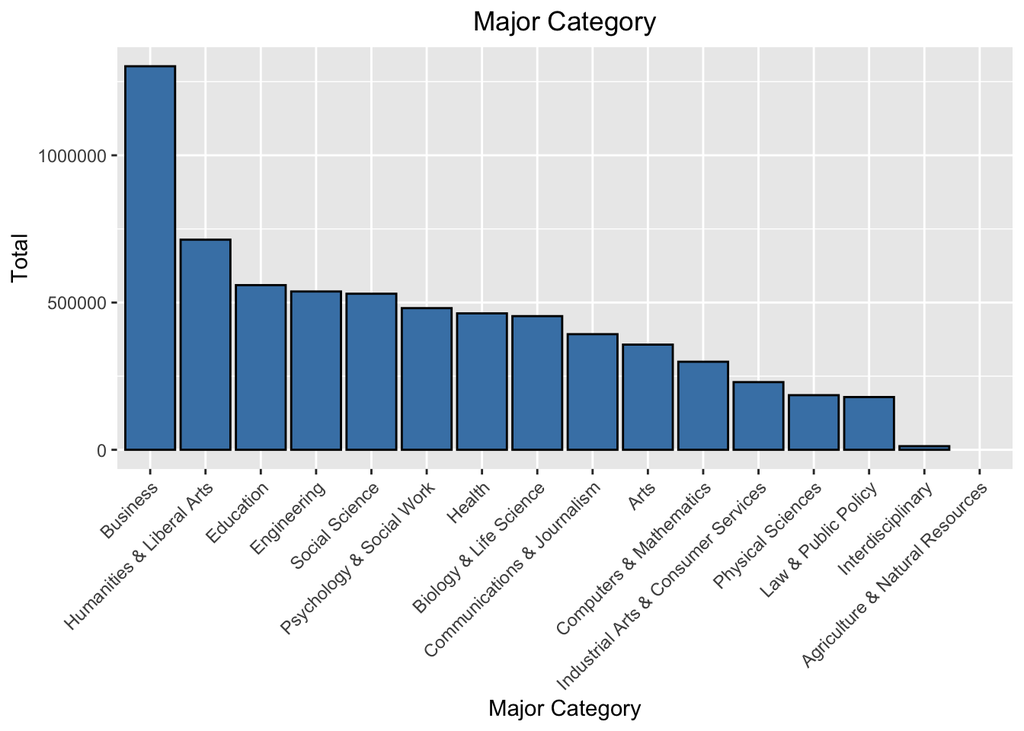

```r
p <- ggplot(new, aes(x=reorder(Major_category,-Total), y= Total)) + ggtitle("Major Category") + theme(plot.title=element_text(hjust=0.5))+theme(axis.text.x=element_text(angle=45,hjust=1))+ xlab("Major Category")+ ylab("Total")+
geom_bar(stat = "identity",fill = "steelblue", color = "black")
p + scale_y_continuous(labels = function(x) format(x, scientific = FALSE))
```

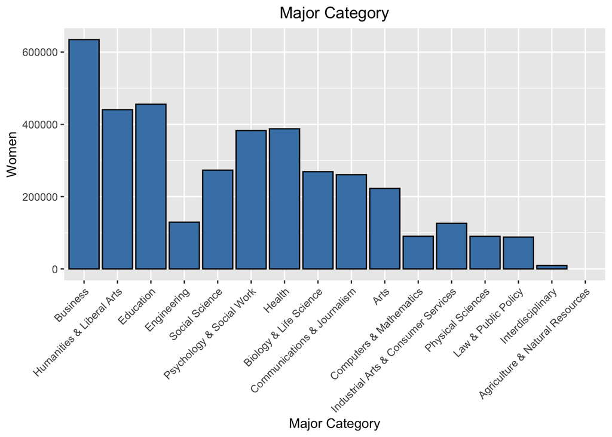

```r
p <- ggplot(new, aes(x=reorder(Major_category,-Total), y= Women)) + ggtitle("Major Category") + theme(plot.title=element_text(hjust=0.5))+theme(axis.text.x=element_text(angle=45,hjust=1))+ xlab("Major Category")+ ylab("Women")+
geom_bar(stat = "identity",fill = "steelblue", color = "black")
p + scale_y_continuous(labels = function(x) format(x, scientific = FALSE))
```

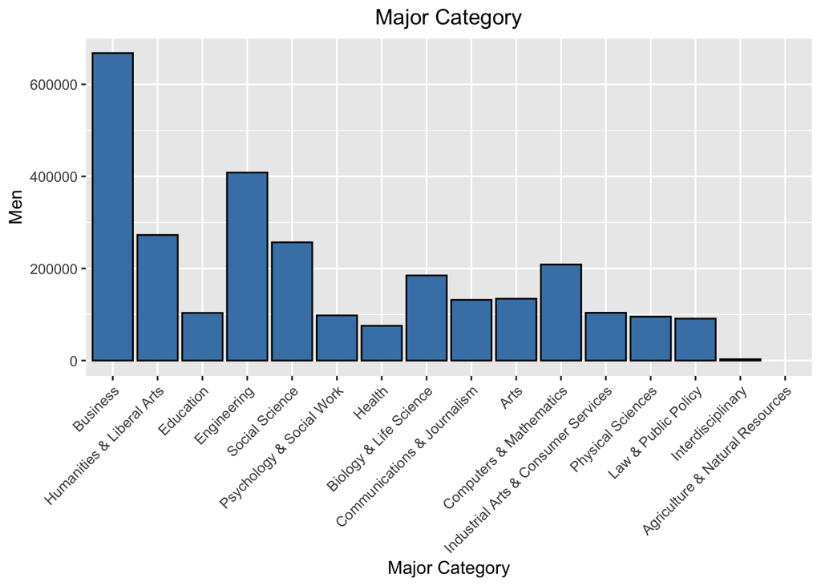

```r
p <- ggplot(new, aes(x=reorder(Major_category,-Total), y= Men)) + ggtitle("Major Category") + theme(plot.title=element_text(hjust=0.5))+theme(axis.text.x=element_text(angle=45,hjust=1))+ xlab("Major Category")+ ylab("Men")+
geom_bar(stat = "identity",fill = "steelblue", color = "black")
p + scale_y_continuous(labels = function(x) format(x, scientific = FALSE))
```

## Median Wage

Below we have a table of the top 20 majors that have highest median wage. Most of these majors belong in the engineering category.

```r
summary(recentgrad$Median)
```

```
##    Min. 1st Qu.  Median    Mean 3rd Qu.    Max.
##   22000   33000   36000   40151   45000  110000
```

```r
top20median<-top_n(recentgrad, 20, Median)
datatable(top20median)
```

|  | Rank | Major_code | Major | Total | Men | Women | Major_category | ShareWomen | Sample_size | Employed | Full_time | Part_time | Full_time_year_round | Unemployed | Unemployment_rate | Median | P25th | P75th | College_jobs | Non_college_jobs | Low_wage_jobs |
| --- | --- | --- | --- | --- | --- | --- | --- | --- | --- | --- | --- | --- | --- | --- | --- | --- | --- | --- | --- | --- | --- |
| 1 | 1 | 2419 | PETROLEUM ENGINEERING | 2339 | 2057 | 282 | Engineering | 0.120564344 | 36 | 1976 | 1849 | 270 | 1207 | 37 | 0.018380527 | 110000 | 95000 | 125000 | 1534 | 364 | 193 |
| 2 | 2 | 2416 | MINING AND MINERAL ENGINEERING | 756 | 679 | 77 | Engineering | 0.101851852 | 7 | 640 | 556 | 170 | 388 | 85 | 0.117241379 | 75000 | 55000 | 90000 | 350 | 257 | 50 |
| 3 | 3 | 2415 | METALLURGICAL ENGINEERING | 856 | 725 | 131 | Engineering | 0.153037383 | 3 | 648 | 558 | 133 | 340 | 16 | 0.024096386 | 73000 | 50000 | 105000 | 456 | 176 | 0 |
| 4 | 4 | 2417 | NAVAL ARCHITECTURE AND MARINE ENGINEERING | 1258 | 1123 | 135 | Engineering | 0.107313196 | 16 | 758 | 1069 | 150 | 692 | 40 | 0.050125313 | 70000 | 43000 | 80000 | 529 | 102 | 0 |
| 5 | 5 | 2405 | CHEMICAL ENGINEERING | 32260 | 21239 | 11021 | Engineering | 0.341630502 | 289 | 25694 | 23170 | 5180 | 16697 | 1672 | 0.061097712 | 65000 | 50000 | 75000 | 18314 | 4440 | 972 |
| 6 | 6 | 2418 | NUCLEAR ENGINEERING | 2573 | 2200 | 373 | Engineering | 0.144966965 | 17 | 1857 | 2038 | 264 | 1449 | 400 | 0.177226407 | 65000 | 50000 | 102000 | 1142 | 657 | 244 |
| 7 | 7 | 6202 | ACTUARIAL SCIENCE | 3777 | 2110 | 1667 | Business | 0.441355573 | 51 | 2912 | 2924 | 296 | 2482 | 308 | 0.095652174 | 62000 | 53000 | 72000 | 1768 | 314 | 259 |
| 8 | 8 | 5001 | ASTRONOMY AND ASTROPHYSICS | 1792 | 832 | 960 | Physical Sciences | 0.535714286 | 10 | 1526 | 1085 | 553 | 827 | 33 | 0.021167415 | 62000 | 31500 | 109000 | 972 | 500 | 220 |
| 9 | 9 | 2414 | MECHANICAL ENGINEERING | 91227 | 80320 | 10907 | Engineering | 0.119558903 | 1029 | 76442 | 71298 | 13101 | 54639 | 4650 | 0.057342278 | 60000 | 48000 | 70000 | 52844 | 16384 | 3253 |
| 10 | 10 | 2408 | ELECTRICAL ENGINEERING | 81527 | 65511 | 16016 | Engineering | 0.196450256 | 631 | 61928 | 55450 | 12695 | 41413 | 3895 | 0.059173845 | 60000 | 45000 | 72000 | 45829 | 10874 | 3170 |

[output cut: 10 more lines]

```r
top20lowestunemployment<-top_n(recentgrad, -20, Unemployment_rate)
datatable(top20lowestunemployment)
```

|  | Rank | Major_code | Major | Total | Men | Women | Major_category | ShareWomen | Sample_size | Employed | Full_time | Part_time | Full_time_year_round | Unemployed | Unemployment_rate | Median | P25th | P75th | College_jobs | Non_college_jobs | Low_wage_jobs |
| --- | --- | --- | --- | --- | --- | --- | --- | --- | --- | --- | --- | --- | --- | --- | --- | --- | --- | --- | --- | --- | --- |
| 1 | 1 | 2419 | PETROLEUM ENGINEERING | 2339 | 2057 | 282 | Engineering | 0.120564344 | 36 | 1976 | 1849 | 270 | 1207 | 37 | 0.018380527 | 110000 | 95000 | 125000 | 1534 | 364 | 193 |
| 2 | 3 | 2415 | METALLURGICAL ENGINEERING | 856 | 725 | 131 | Engineering | 0.153037383 | 3 | 648 | 558 | 133 | 340 | 16 | 0.024096386 | 73000 | 50000 | 105000 | 456 | 176 | 0 |
| 3 | 8 | 5001 | ASTRONOMY AND ASTROPHYSICS | 1792 | 832 | 960 | Physical Sciences | 0.535714286 | 10 | 1526 | 1085 | 553 | 827 | 33 | 0.021167415 | 62000 | 31500 | 109000 | 972 | 500 | 220 |
| 4 | 14 | 5008 | MATERIALS SCIENCE | 4279 | 2949 | 1330 | Engineering | 0.310820285 | 22 | 3307 | 2751 | 878 | 1967 | 78 | 0.023042836 | 60000 | 39000 | 65000 | 2626 | 391 | 81 |
| 5 | 15 | 2409 | ENGINEERING MECHANICS PHYSICS AND SCIENCE | 4321 | 3526 | 795 | Engineering | 0.183985189 | 30 | 3608 | 2999 | 811 | 2004 | 23 | 0.006334343 | 58000 | 25000 | 74000 | 2439 | 947 | 263 |
| 6 | 20 | 3201 | COURT REPORTING | 1148 | 877 | 271 | Law &amp; Public Policy | 0.236062718 | 14 | 930 | 808 | 223 | 808 | 11 | 0.011689692 | 54000 | 50000 | 54000 | 402 | 528 | 144 |
| 7 | 24 | 2413 | MATERIALS ENGINEERING AND MATERIALS SCIENCE | 2993 | 2020 | 973 | Engineering | 0.325091881 | 22 | 2449 | 1658 | 1040 | 1151 | 70 | 0.027788805 | 52000 | 35000 | 62000 | 1911 | 305 | 70 |
| 8 | 39 | 2503 | INDUSTRIAL PRODUCTION TECHNOLOGIES | 4631 | 3477 | 1154 | Engineering | 0.24919024 | 73 | 4428 | 3988 | 597 | 3242 | 129 | 0.028308097 | 46000 | 35000 | 65000 | 1394 | 2454 | 480 |
| 9 | 51 | 2501 | ENGINEERING AND INDUSTRIAL MANAGEMENT | 2906 | 2400 | 506 | Engineering | 0.174122505 | 29 | 2125 | 1992 | 462 | 1358 | 74 | 0.03365166 | 44000 | 30000 | 50000 | 482 | 844 | 245 |
| 10 | 53 | 4005 | MATHEMATICS AND COMPUTER SCIENCE | 609 | 500 | 109 | Computers &amp; Mathematics | 0.178981938 | 7 | 559 | 584 | 0 | 391 | 0 | 0 | 42000 | 30000 | 78000 | 452 | 67 | 25 |

[output cut: 10 more lines]

# Conclusion

I would consider to look further/verify into careers path that also may require more than just a bachelor degree. We should also take into consideration of jobs that do not need a college major as a qualification.